# Adrien HANS & Tanguy JEANNEAU

# T.P. 1: Discrete time homogeneous Markov chains

## General instructions:

- make sure the notebook you produce is properly annotated: each exercise should be introduced by a short sentence summarizing its context. Concisely answer each question from the guideline;
- include appropriate axis labels and a relevant title to each figure reported in the notebook;
- document any function you introduce (using docstrings), and comment your code whenever apporpriate (see, *e.g.*, [PEP 8 style recommendations](https://www.python.org/dev/peps/pep-0008/));
- clearly structure your notebook: longer theoretical explanations should be reported in markdown cells. Do not hesitate to include LaTeX equations to improve the clarity of the document.

**We make the necessary imports:**

```python
import numpy as np
import scipy
import seaborn as sns
import matplotlib.pyplot as plt

#For multiprocessing :
import multiprocessing as mp
```

## Exercise 1: Ehrenfest model

Consider a system of $K = 50$ particles (labeled from 1 to $K$) evolving in a closed box. The box is divided into two compartments in contact with each other, respectively identified by an index, 0 and 1. A hole at the interface between the two compartments allows the particles to move from one compartment to the other.

Particle motion is modeled as follows: at each discrete time intant $n$, one particle is chosen uniformly at random and moved from its current compartment to the other. Let $X(n)$ denote the number of particles in compartment 0 at time $n$.

1. Briefly justify that $\bigl(X(n) \bigr)_{n \in \mathbb{N}}$ is a Markov chain.

**$\bigl(X(n) \bigr)_{n \in \mathbb{N}}$ is a Markov chain because it is a family $\bigl(X(n) \bigr)_{n \in \mathbb{N}}$ of random variables indexed by natural numbers and satisfying the markov property :**

$$ P(X(n)=i_n|X(n-1)=i_{n-1},..., X(0)=i_0)=P(X(n)=i_n|X(n-1)=i_{n-1})$$

2. Recall the structure of the transition matrix, and encode it in Python (without any for loop).

> Hint: use the function `numpy.diag`.

**The structure of the transition matrix is a matrix of $p_{i,j}$ the probability of getting from state $i$ to state $j$ at a given discrete time n.**

In this particular case, we can only go from one state $i$ to the state $i-1$ or $i+1$. At a certain time, the probability of getting from state $i$ to state $i+1$ is $p$ and the probability of getting from state $i$ to state $i-1$ is $1-p$.

Therefore, the transition matrix is null, except the sub-diagonal and the upper diagonal, equal respectively to $1-p$ and $p$.

Since the particle moving from one compartiment to the other is chosen uniformly at random, $p$ at the given time $n$ is equal to $\frac{50-X(n)}{50}$.

We plot below the transition matrix for K=50 particles as a heatmap for more convenience :

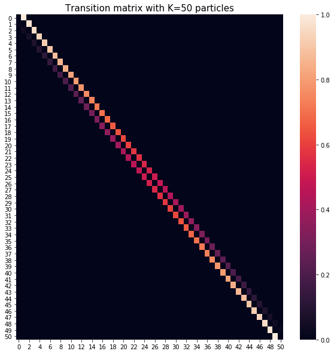

```python
def create_P(K):
    """
    Function create_P : to compute the transition matrix P associated with the Ehrenfest model
    @Inputs :
        K : int, the number of states considered in the markov chain
    @Outputs :
        the transition matrix associated with the Ehrenfest model
    """
    upper_diag = [(K-n)/K for n in range (0,K)]
    lower_diag =[n/K for n in range (1,K+1)]
    #Transition matrix P :
    return np.diag(upper_diag, k=1) + np.diag(lower_diag, k=-1)
#K=50 particles
K=50
#We create P :
P=create_P(K)
#Initialization of the matplotlib figure :
fig=plt.figure(figsize=(10,10))
#Plotting the matrix as a heatmap :
plt.title('Transition matrix with K=50 particles',size=15)
sns.heatmap(P)
```

3. Numerically verify that the binomial distribution $\mathcal{B} (K, 1/2)$ is invariant for the chain. This invariant distribution will be denoted by $\pi$ in the rest of the exercise.

> Hint: use `scipy.special.binom`.

**We write a function to create pi :**

```python
def create_pi(K):
    """
    Function create_pi : to cumpute the invariant distribution pi for the Ehrenfest model
    @Inputs :
        K : int, the number of states considered in the markov chain
    @Outputs :
        array, the invariant distribution pi computed from the binomial distribution B(K,1/2)
    """
    return np.array([scipy.special.binom(K,i)*(0.5)**i*(0.5)**(K-i) for i in range(K+1)])
#we compute pi with K=50 states :
pi=create_pi(50)
```

```python
diff = np.linalg.norm(np.dot(pi, P) - pi)
print('the difference in norm between pi*P and pi is : ', diff)
```

```
the difference in norm between pi*P and pi is :  8.740153268289626e-17
```

**We see that the difference between $\pi P$ and $\pi$ is very close to zero, so $\pi$ is indeed the invariant distribution for this chain.**

4. Implement a Python function `ehrenfest` simulating a trajectory of the chain for a system of N particles, of initial distribution $\mu$. The maximum number of time steps will be controlled by an input parameter $n_\max$.

> Remarks:
> - for conveninence, you may define the state of a particle as a boolean variable. Changing the state of a particle will thus reduce to toggling the state of the associated boolean variable;
> - note that, for any $i \in \{ 1, \dotsc , K \}$, imposing $X(0) = i$ means that the initial probability distribution $\mu$ is a Dirac centered in $i$.

```python
def ehrenfest(N, mu, nmax):
    """
    function ehrenfest(N, mu, nmax) simulating a trajectory of the chain for a system of N particles
    @Inputs :
        - N, int : the number of particles
        - mu, array : the initial distribution
        - nmax, int : the maximum number of time steps
    @Outputs :
        -states, array : the successive states visited by the chain
    """
    P=create_P(N)
    next_step=np.random.choice(N+1, p=mu)
    states=[next_step]
    for i in range(nmax-1):
        next_step=np.random.choice(N+1, p=P[next_step])
        states.append(next_step)
    return states
```

5. Simulate a trajectory of the chain starting in state $0$ for $K = 100$ particles and $n_\max = 10000$. Display the result in function of the time index $n$.

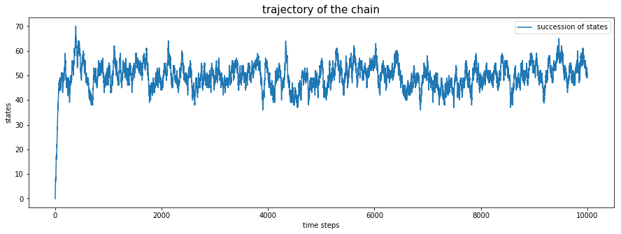

```python
#Number of particles : K=100
K=100
#maximum number of time steps nmax=10 000
nmax=10000
#Initialization of mu so that the chain starts in state 0 :
mu=np.array([1]+[0]*K)
#Computing the trajectory thanks to ehrenfest(K, mu, nmax) :
states=ehrenfest(K, mu, nmax)
#Initializing the figure :
fig=plt.figure(figsize=(15,5))
# Plotting the successive states visited  :
plt.plot(range(nmax), states, label='succession of states')
plt.title('trajectory of the chain', size=15)
plt.xlabel('time steps')
plt.ylabel('states')
plt.legend()
plt.show()
```

6. Compare the empirical histogram of the trajectory obtained in 5. to the theoretical limit distribution $\pi$. What do you observe?

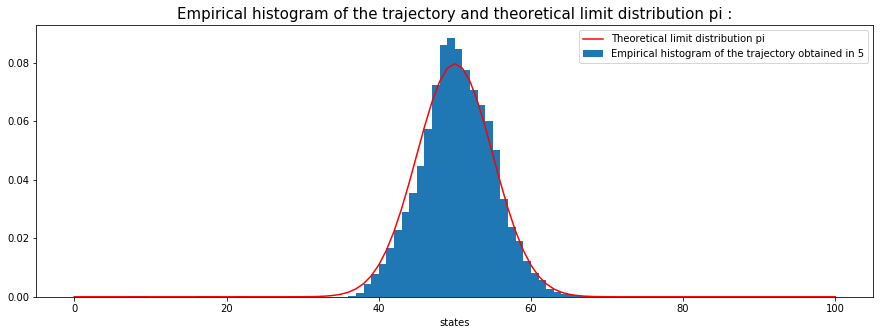

```python
pi=create_pi(K)
fig=plt.figure(figsize=(15,5))
plt.hist(states,bins=70, normed=True, label='Empirical histogram of the trajectory obtained in 5')
plt.plot(range(K+1), pi, color='r', label='Theoretical limit distribution pi')
plt.legend()
plt.title('Empirical histogram of the trajectory and theoretical limit distribution pi :', size=15)
plt.xlabel('states')
plt.show()
```

**We observe that the empirical histogram of the trajectory obtained in 5) follows the theoretical limit distribution $\pi$**

7. Compute $(\mu_n)_{1 \leq n \leq n_{\max}}$, where $\mu_n \triangleq \mu P^n$ is the probability distribution of $X$ at time $n$ (*i.e.*, $\mu_n = ( \mathbb{P}[X(n) = k] )_{1 \leq k \leq K} \in [0, 1]^K$).

```python
#Number of particles :
K=100
#nmax= 1000 the number of mu_n computed :
nmax=1000

P=np.array(create_P(K))
mu=np.array([1]+[0]*K)

P_n=np.array(mu.dot(P))
mu_n=np.array([P_n])

for n in range(nmax-1):
    P_n = P_n.dot(P)
    mu_n=np.append(mu_n, [P_n],axis=0)
```

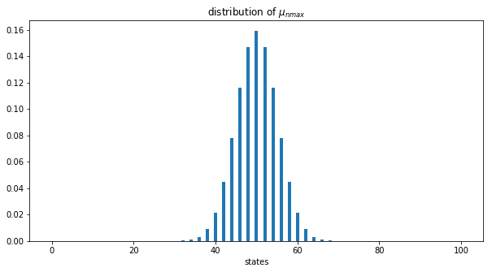

```python
fig =plt.figure(figsize=(10,5))
plt.bar(range(K+1), mu_n[-1])
plt.title('distribution of $\mu_{nmax}$')
plt.xlabel('states')
plt.show()
```

8. Plot the function $n \mapsto \Vert \mu_n - \pi \Vert_1$, where $\Vert \cdot \Vert_1$ is the $\ell_1$ norm. What does this curve illustrate?

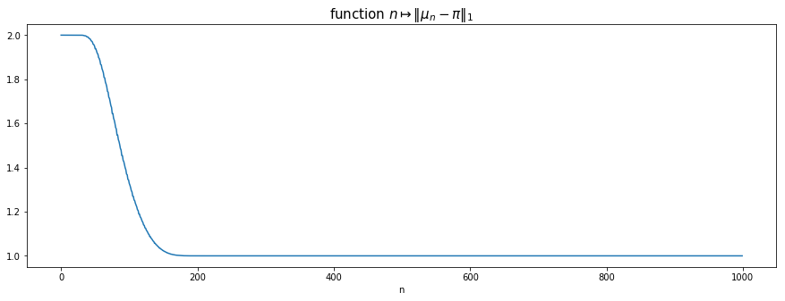

```python
pi=create_pi(K)
normes=np.linalg.norm((mu_n-pi),ord=1,axis=1)
fig=plt.figure(figsize=(15, 5))
plt.plot(range(nmax), normes)
plt.title('function $n \mapsto \Vert \mu_n - \pi \Vert_1$', size=15)
plt.xlabel('n')
plt.show()
```

**We notice that the norm 1 converges towards 1. It might seem surprising at first glance, beccause we could expect that $\mu_n$ -> $\pi$ when n -> $\infty$. However, when having a detailed look at $\mu_n$ we understand where this is coming from :**

**AT each iteration, the state can be either incremented or decremented. This means that, when starting at X(0) = 0, the even indexes i can only be reached at even times n, and the odd indexes i can only be reached at odd times n.**

**This illustrates the fact that this markov chain is periodic.**

We can notice that by plotting a given Mu*n for an even n, then for an odd n, then averaging the two to get a smooth gaussian curve. We can say that $\frac{\mu*{2k}+\mu_{2k+1}}{2} - \pi$ -> 0

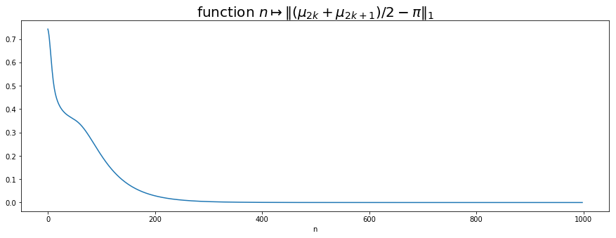

```python
pi=create_pi(K)
normes=[np.linalg.norm((mu_n[i+1]+mu_n[i])/2-pi) for i in range(nmax-1)]
fig=plt.figure(figsize=(15, 5))
plt.plot(range(nmax-1), normes)
plt.title('function $n \mapsto \Vert (\mu_{2k}+\mu_{2k+1})/2-\pi \Vert_1$', size=20)
plt.xlabel('n')
plt.show()
```

**We see by ploting the function $n \mapsto \Vert \frac{\mu_{2k}+\mu_{2k+1}}{2} - \pi \Vert_1$ that it converges this time to 0**

1. a) Modify the function defined in 1. so that it returns the return time to state 0, defined as $T_{0,0} = \inf \bigl\{ n > 0, X(n) = 0 \mid X(0) = 0 \bigr\}$.

**We modify the function `ehrenfest(N, mu, nmax)` to obtain `ehrenfest_return_time(N,mu)` which returns the return time to state 0 :**

```python
def ehrenfest_return_time(N, mu):
    """
    function ehrenfest_return_time(N, mu) simulating the return time of the chain to state 0
    @Inputs :
        - N, int : the number of particles
        - mu, array : the initial distribution
    @Outputs :
        -return_time, int : the return time to 0
    """
    P=create_P(N)
    next_step=np.random.choice(N+1, p=mu)
    return_time=0
    step=1
    while step != 0:
        next_step=np.random.choice(N+1, p=P[next_step])
        return_time+=1
        step=next_step
    return return_time
```

**We compute the return time for K=10 particles because it becomes difficult to compute with a large K**

```python
#Number of particles :
K=10
#We define mu so that the markov chain starts from state 0:
mu=np.array([1]+[0]*K)

print('return time :',  ehrenfest_return_time(K, mu))
```

```
return time : 52
```

b) Run several chains (about 10, ideally in parallel) and compare the empirical average of $T_{0,0}$ to $\pi(0)$.

> Hint: a good tutorial showing how to run functions in parallel in Python is available [here](https://www.machinelearningplus.com/python/parallel-processing-python/).

**We use the code and follow the tutorial along with this medium article to make it work on windows :**

https://medium.com/@grvsinghal/speed-up-your-python-code-using-multiprocessing-on-windows-and-jupyter-or-ipython-2714b49d6fac

To solve errors, we save the function `ehrenfest_return_time(K,mu)` in a file `ehrenfest_multi.py` that we import together with the `multiprocessing` package.

```python
import ehrenfest_multi
```

```python
print("Number of processors: ", mp.cpu_count())
```

```
Number of processors:  8
```

```python
def Ehrenfest_parallel(K,mu,n_chains):
    if __name__ ==  '__main__':  #additional line to make it work on windows and Jupyter
        # Step 1: Init multiprocessing.Pool()
        pool = mp.Pool(mp.cpu_count())
        #Getting the processors to work in parallel
        #We use starmap to be able to to compute the function ehrenfest_return_time which takes several arguments.
        output = pool.starmap(ehrenfest_multi.ehrenfest_return_time, [(K,mu) for i in range(0,n_chains)])
        pool.close
        return output
```

```python
#Number of particles :
K=10
#We define mu so that the markov chain starts from state 0:
mu=np.array([1]+[0]*K)

n_chains=10
output=Ehrenfest_parallel(K,mu,n_chains)
for i in range (0,n_chains):
    print('process : \n', output[i],' \n')
```

```
process :
 1106

process :
 1170

process :
 1456

process :
 940

process :
 578

process :
 686

process :
 1402

process :
 4508

process :
 492

process :
 2
```

**We compute the mean empirical return time of those 10 obtained by running 10 markov chains in parallel and compare it to $\frac{1}{\pi(0)}$ instead of $\pi(0)$ because it seems more accurate:**

```python
print('Mean empirical return time : ', np.mean(output))
print('1/pi(0) : ', 1/create_pi(K)[0])
```

```
Mean empirical return time :  1234.0
1/pi(0) :  1024.0
```

We observe that the mean empirical return time and $\frac{1}{\pi(0)}$ are quite close.

c) Based on the results obtained in TD. 1 Exercise 3, comment on the possibility of numerically observing the chain returning to its initial state.

```
For K=10.00 particles, 1/pi(0) =  1024.0
For K=20.00 particles, 1/pi(0) =  1048576.0
For K=30.00 particles, 1/pi(0) =  1073741824.0
For K=40.00 particles, 1/pi(0) =  1099511627776.0
For K=50.00 particles, 1/pi(0) =  1125899906842624.0
For K=60.00 particles, 1/pi(0) =  1.152921504606847e+18
For K=70.00 particles, 1/pi(0) =  1.1805916207174113e+21
For K=80.00 particles, 1/pi(0) =  1.2089258196146292e+24
For K=90.00 particles, 1/pi(0) =  1.2379400392853803e+27
For K=100.00 particles, 1/pi(0) =  1.2676506002282294e+30
```

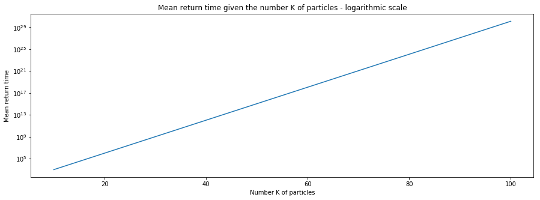

```python
inverse_pi0=[]
for K in range(10,110,10):
    print("For K={K:.2f} particles, 1/pi(0) = ".format(K=K), 1/create_pi(K)[0])
    inverse_pi0.append(1/create_pi(K)[0])
fig=plt.figure(figsize=(15,5))
plt.plot(range(10,110,10), inverse_pi0)
plt.yscale('log')
plt.title('Mean return time given the number K of particles - logarithmic scale')
plt.xlabel('Number K of particles')
plt.ylabel('Mean return time')
plt.show()
```

We see on the figure above that the mean return time is exponential in the number K of particles.

Therefore, for a high number of particles, it is not possible numerically to observe the chain returning to its initial state.

This is why for the computations above we tried to find the mean empirical return time only for 10 particles.

## Exercise 2: Simulation of a discrete time homogeneous Markov chain.

Let $\bigl( X(n) \bigr)_{n \in \mathbb{N}}$ be a discrete time homogeneous Markov chain defined by the following initial distribution $\mu$ and transition matrix $P$

\begin{equation} \mu = [0, 1, 0, 0, 0, 0], % \quad % P = \begin{pmatrix} 1/2 &1/2 &0 &0 &0 &0 \\ 1/4 &0 &0 &1/4 &1/4 &1/4 \\ 1/2 &0 &0 &0 &0 &1/2 \\ 0 &1/2 &0 &0 &1/2 &0 \\ 0 &1/3 &0 &1/3 &0 &1/3 \\ 0 &1/3 &1/3 &0 &1/3 &0 \end{pmatrix}. \end{equation}

1. Write a function `simulate_dthmc` simulating the trajectory of the Markov chain $\bigl( X(n) \bigr)_{n \in \mathbb{N}}$ for $n_{\max}$ time steps. The signature of the function should include the following elements:

- list of inputs: transition matrix $P$, initial distribution $\mu$, number of time steps $n_{\max}$;
- output: array of lenght $n_{\max}$ representing the trajectory.

```python
def simulate_dthmc(P,mu,nmax):
    """
    function simulate_dthmc(P, mu, nmax) simulating a trajectory of the chain for a system of N particles
    @Inputs :
        - P, array : the transition matrix
        - mu, array : the initial distribution
        - nmax, int : the maximum number of time steps
    @Outputs :
        -states, array of length nmax : the successive states visited by the chain
    """
    next_step=np.random.choice(P.shape[0], p=mu)
    trajectory=[next_step]
    for i in range(nmax-1):
        next_step=np.random.choice(P.shape[0], p=P[next_step])
        trajectory.append(next_step)
    return np.array(trajectory)
```

2. Simulate a trajectory of the chain for $n_{\max} = 2000$ starting from $X(0) = 1$. Plot the histogram of the states visited by the chain.

```python
#Initialization of P :
P = np.array([
    [1/2  , 1/2  , 0  , 0  , 0  , 0],
    [1/4, 0  , 0  , 1/4, 1/4, 1/4],
    [1/2  , 0  , 0  , 0  , 0  , 1/2],
    [0  , 1/2, 0  , 0  , 1/2, 0  ],
    [0  , 1/3, 0  , 1/3, 0  , 1/3],
    [0  , 1/3, 1/3, 0  , 1/3, 0  ]
])
#initialization of mu so that X(0)=1 :
mu=np.array([0,1,0,0,0,0])
#initialization of nmax :
nmax=2000
```

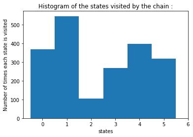

```python
#Computing the trajectory :
trajectory=simulate_dthmc(P,mu,nmax)
#Plotting the histogram :
fig, ax = plt.subplots()
#Trick to have the bars of the histogram in front of each number of state associated :
bins = np.arange(0, trajectory.max() + 1.5) - 0.5
_=ax.hist(trajectory, bins)
ax.set_xticks(bins+0.5)
plt.title('Histogram of the states visited by the chain :')
plt.xlabel('states')
plt.ylabel('Number of times each state is visited')
plt.show()
```

3. Determine numerically the invariant distribution $\boldsymbol{\pi}$ of the chain (*e.g.*, based on an eigendecomposition [numpy.linalg.eig](https://docs.scipy.org/doc/numpy/reference/generated/numpy.linalg.eig.html)). Compare it to the histogram obtained in 2.

```python
# we compute the eigenvalues and the eigenvectors of P.T
eigenvalues, eigenvectors = np.linalg.eig(P.transpose())

#We search the eigenvector associated to the eigenvalue 1 :
pos_values_dom = np.argmax(eigenvalues)
vec_dom = eigenvectors[:, pos_values_dom]

# We verify that the eigenvalue is indeed equal to one
assert abs(np.max(eigenvalues) - 1) < 1e-10

#We find the eigenvector associated and we make sure that the sum of its composants is equal to one :
pi = eigenvectors[:,pos_values_dom]/np.sum(vec_dom)
```

```python
#we compute the difference between pi*P and pi :
diff = np.linalg.norm(np.dot(pi,P)-pi)
print('The difference in norm between pi*P and pi is : ', diff)
print('The sum of the composants of pi is : ', pi.sum())
```

```
The difference in norm between pi*P and pi is :  2.0062885096040707e-16
The sum of the composants of pi is :  (0.9999999999999999+0j)
```

Just like before, we have indeed numerically: $$|\pi P - \pi|<10^{-15}|$$

Thus, we can say that $$\pi P = \pi$$

Also, we verified that the sum of the composants of $\pi$ is equal to one.

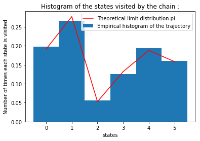

```python
#Computing the trajectory :
trajectory=simulate_dthmc(P,mu,nmax)
#Plotting the histogram :
fig, ax = plt.subplots()
#Trick to have the bars of the histogram in front of each number of state associated :
bins = np.arange(0, trajectory.max() + 1.5) - 0.5
_=ax.hist(trajectory, bins,normed=True, label='Empirical histogram of the trajectory')
ax.set_xticks(bins+0.5)
plt.title('Histogram of the states visited by the chain :')
plt.xlabel('states')
plt.ylabel('Number of times each state is visited')
plt.plot(range(6), pi, color='r', label='Theoretical limit distribution pi')
plt.legend()
plt.show()
```

**We see once again that the invariant distribution $\pi$ follows the empirical histrogram of the trajectory**

4. a) Compute $\mu_n \triangleq \mu P^n$, the probability distribution of $X(n)$. What is the limit of $\mu_n$ as $n$ goes to $+\infty$?

```python
# We take a similar code as the one used in the previous section :

#Number of mu_n nmax we want to cumpute :
nmax=150
#initialization of mu so that X(0)=1 :
mu=np.array([0,1,0,0,0,0])

P_n=np.array(mu.dot(P))
mu_n=np.array([P_n])
for n in range(nmax-1):
    P_n = P_n.dot(P)
    mu_n=np.append(mu_n, [P_n],axis=0)
```

**Limit of $\mu_n$ as $n$ goes to $+\infty$ :**

We print $\mu_{nmax}$ :

```python
print(mu_n[-1])
```

```
[0.19141914 0.27722772 0.05280528 0.1320132  0.18811881 0.15841584]
```

We print $\pi$ :

```python
print(pi)
```

```
[0.19141914-0.j 0.27722772-0.j 0.05280528-0.j 0.1320132 -0.j
 0.18811881-0.j 0.15841584-0.j]
```

We clearly see that $\mu_{nmax}$ and $\pi$ are equal but we can verify it :

```python
print(np.linalg.norm(mu_n[-1]-pi))
```

```
1.196712792045923e-15
```

**Therefore,** $$|\mu_{nmax} -\pi | \approx 0$$

**We can clearly say that as $n$ goes to $+\infty$, $\mu_n$ goes to $\pi$**

b) Display on the same graph the curves $n \mapsto \mu_n(i)$ for $i = 1, \dotsc , 6$, and compare with $\pi$. What do you observe?

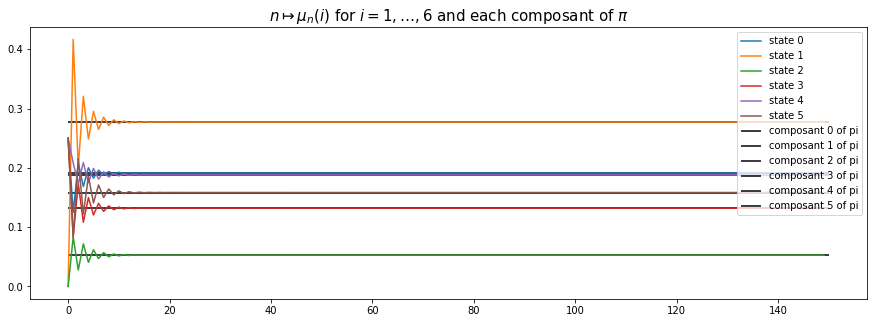

```python
fig=plt.figure(figsize=(15,5))
for i in range(mu_n.shape[1]):
    plt.plot(mu_n[:,i], label=str('state '+ str(i)))
    plt.hlines(pi[i], xmin=0, xmax=nmax, label=str( 'composant ' + str(i) +' of pi'))
    plt.legend()
plt.title('$n \mapsto \mu_n(i)$ for $i = 1, \dots , 6$ and each composant of $\pi$', size=15)
plt.show()
```

**We can clearly see that each $n \mapsto \mu_n(i)$ for $i = 1, \dotsc , 6$ converges quite rapidly to the composant of $\pi$ associated**

c) Display on another graph the function $n \mapsto \Vert \mu_n - \pi \Vert_1$, where $\Vert \cdot \Vert_1$ is the $\ell_1$ norm. What does this curve illustrate?

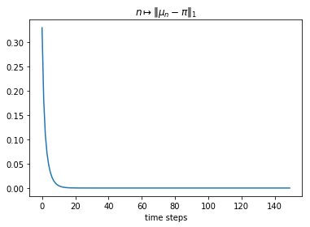

```python
normes=[np.linalg.norm(mu_n[i,:]-pi) for i in range(mu_n.shape[0])]
plt.plot(range(nmax), normes)
plt.title('$n \mapsto \Vert \mu_n - \pi \Vert_1$')
plt.xlabel('time steps')
plt.show()
```

**This curve illustrate once again the convergence of $\mu_n$ to $\pi$**

5. For each state $i \in \{1, \dotsc, 5 \}$, simulate 1000 trajectories starting from the state $i$ until the return time to $i$. For each state, compute the (empirical) average return time. Compare with its theoretical value.

```python
def simulate_dthmc_return_time(P,mu,i):
    next_step=np.random.choice(P.shape[0], p=mu)
    return_time=0
    if i !=0:
        step=i-1
    else:
        step=1
    while step != i:
        next_step=np.random.choice(P.shape[0], p=P[next_step])
        return_time+=1
        step=next_step
    return return_time
```

```python
#We want to simulate n_traj=1000 trajectories
n_traj=1000
#We save the empirical average return time in 'avg_return_time' :
avg_return_time=[]

for i in range(6):
    #We count each return time in 'return_time' :
    return_time=[]
    #we define mu so that the markov chain starts from state i :
    mu=np.array([0]*(i)+[1]+[0]*(5-i))
    for j in range(n_traj):
        return_time.append(simulate_dthmc_return_time(P,mu,i))
    avg_return_time.append(np.mean(return_time))

print('empirical mean return time for each state i : ', avg_return_time)
```

```
empirical mean return time for each state i :  [5.379, 3.431, 18.264, 7.839, 5.283, 6.235]
```

**the theoretical value of the average return time $T_{i,i}$ is $\frac{1}{\pi_i}$**

```python
print('theoretical mean return time for each state i : ', 1/pi)
```

```
theoretical mean return time for each state i :  [ 5.22413793+0.j  3.60714286+0.j 18.9375    +0.j  7.575     +0.j
  5.31578947+0.j  6.3125    +0.j]
```

**We can compare those values -theoretical and empirical- for each state i :**

```python
for i in range(6):
    print('state ', i, " :")
    print("{rate:.2f} % of difference".format(rate=np.linalg.norm(avg_return_time[i]-1/pi[i])/avg_return_time[i] *100))
```

```
state  0  :
2.88 % of difference
state  1  :
5.13 % of difference
state  2  :
3.69 % of difference
state  3  :
3.37 % of difference
state  4  :
0.62 % of difference
state  5  :
1.24 % of difference
```

**Therefore, we can say that the empirical results are really close to the theoretical results.**